# Functional Response Lab Analysis

# 1 Read in and clean up data

```r
# Read in data
#  fr_dat <- read.csv(file = "~/FunctionalResponseLab/FuncResp.csv")
  fr_dat <- read.csv(file = '/Users/cmmoore/Library/CloudStorage/GoogleDrive-cmmoore@colby.edu/My Drive/Courses/BI382/2025Spring/Labs/FuncResp/FuncResp.csv')

# Fix Chris' screwup
  fr_dat$Final[24] <- 6
```

# 2 Modify data for analysis

```r
# Add removal column since this is what we want to measure
  fr_dat$Removed <- fr_dat$Initial - fr_dat$Final

# Create sandpaper and peanut indices and create own dataframes
  sand_ind <- which(fr_dat$PreyType == "Sandpaper")
  sand_dat <- fr_dat[sand_ind,]

  pea_ind <- which(fr_dat$PreyType == "Peanuts")
  pea_dat <- fr_dat[pea_ind,]

# Create sandpaper and peanut indices by group (Chris or Nick)
  sandCM_ind <- which(sand_dat$Group == "CM")
  peaCM_ind <- which(pea_dat$Group == "CM")
  sandCM_dat <- sand_dat[sandCM_ind,]
  peaCM_dat <- pea_dat[peaCM_ind,]

  sandNL_ind <- which(sand_dat$Group == "NL")
  peaNL_ind <- which(pea_dat$Group == "NL")
  sandNL_dat <- sand_dat[sandNL_ind,]
  peaNL_dat <- pea_dat[peaNL_ind,]
```

# 3 Create linear and non-linear statistical models

```r
# Linear models
  sand_lm <- lm(sand_dat$Removed ~ sand_dat$Initial - 1)
  pea_lm <- lm(pea_dat$Removed ~ pea_dat$Initial - 1)

  sandCM_lm <- lm(sandCM_dat$Removed ~ sandCM_dat$Initial - 1)
  peaCM_lm <- lm(peaCM_dat$Removed ~ peaCM_dat$Initial - 1)
  sandNL_lm <- lm(sandNL_dat$Removed ~ sandNL_dat$Initial - 1)
  peaNL_lm <- lm(peaNL_dat$Removed ~ peaNL_dat$Initial - 1)

# Non-linear models
  sand_nls <- nls(formula = Removed ~ a*Initial/(1 + a*b*Initial), start = c(a = 0.1, b = 1), data = sand_dat)
  pea_nls <- nls(formula = Removed ~ a*Initial/(1 + a*b*Initial), start = c(a = 0.1, b = 1), data = pea_dat)

  sandCM_nls <- nls(formula = Removed ~ a*Initial/(1 + a*b*Initial), start = c(a = 0.1, b = 1), data = sandCM_dat)
  peaCM_nls <- nls(formula = Removed ~ a*Initial/(1 + a*b*Initial), start = c(a = 0.1, b = 1), data = peaCM_dat)
  sandNL_nls <- nls(formula = Removed ~ a*Initial/(1 + a*b*Initial), start = c(a = 0.1, b = 1), data = sandNL_dat)
  peaNL_nls <- nls(formula = Removed ~ a*Initial/(1 + a*b*Initial), start = c(a = 0.1, b = 1), data = peaNL_dat)
```

# 4 Create fitted lines and curves

```r
# x range
  x_vec <- 0:50

# Extract coefficients from linear models
  sand_m <- sand_lm$coefficients
  pea_m <- pea_lm$coefficients

  sandCM_m <- sandCM_lm$coefficients
  peaCM_m <- peaCM_lm$coefficients
  sandNL_m <- sandNL_lm$coefficients
  peaNL_m <- peaNL_lm$coefficients

# Make expected linear values
  sand_y <- sand_m*x_vec
  pea_y <- pea_m*x_vec

  sandCM_y <- sandCM_m*x_vec
  peaCM_y <- peaCM_m*x_vec
  sandNL_y <- sandNL_m*x_vec
  peaNL_y <- peaNL_m*x_vec

# Extract coefficients from non-linear models
  sand_a <- coefficients(sand_nls)["a"]
  sand_b <- coefficients(sand_nls)["b"]
  pea_a <- coefficients(pea_nls)["a"]
  pea_b <- coefficients(pea_nls)["b"]

  sandCM_a <- coefficients(sandCM_nls)["a"]
  sandCM_b <- coefficients(sandCM_nls)["b"]
  peaCM_a <- coefficients(peaCM_nls)["a"]
  peaCM_b <- coefficients(peaCM_nls)["b"]
  sandNL_a <- coefficients(sandNL_nls)["a"]
  sandNL_b <- coefficients(sandNL_nls)["b"]
  peaNL_a <- coefficients(peaNL_nls)["a"]
  peaNL_b <- coefficients(peaNL_nls)["b"]

# Make expected non-linear values
  sand_nsly <- sand_a*x_vec/(1 + sand_a*sand_b*x_vec)
  pea_nsly <- pea_a*x_vec/(1 + pea_a*pea_b*x_vec)

  sandCM_nsly <- sandCM_a*x_vec/(1 + sandCM_a*sandCM_b*x_vec)
  peaCM_nsly <- peaCM_a*x_vec/(1 + peaCM_a*peaCM_b*x_vec)
  sandNL_nsly <- sandNL_a*x_vec/(1 + sandNL_a*sandNL_b*x_vec)
  peaNL_nsly <- peaNL_a*x_vec/(1 + peaNL_a*peaNL_b*x_vec)
```

# 5 Results

## 5.1 Prey type: sandpaper and peanuts

### 5.1.1 Graphical reuslts

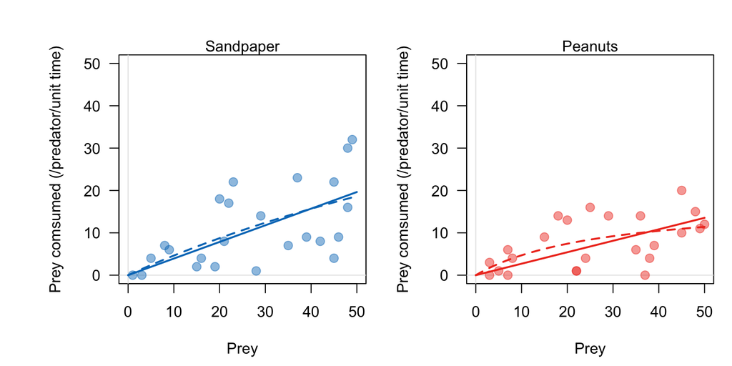

```r
# Make graphs
  par(mfrow = c(1, 2), mar = c(4.5, 4.5, 1, 1), oma = c(0, 2, 2, 0))
  # Sandpaper
  plot(x = NA, type ="n", xlim = c(0, 50), ylim = c(0, 50), xlab = "Prey", ylab = "Prey comsumed (/predator/unit time)", las = 1)
    mtext(side = 3, text = "Sandpaper")
    abline(h = 0, v = 0, col = "grey90")
    points(x = sand_dat$Initial, y = sand_dat$Removed, las = 1, col = "#007ac177", pch = 19, cex = 1.25)
    lines(x = x_vec, y = sand_y, col = "#007ac1", lwd = 2)
    lines(x = x_vec, y = sand_nsly, col = "#007ac1", lty = 2, lwd = 2)
    # Peanuts
  plot(x = NA, type = "n", xlim = c(0, 50), ylim = c(0, 50), xlab = "Prey", ylab = "Prey comsumed (/predator/unit time)", las = 1)
  mtext(side = 3, text = "Peanuts")
  abline(h = 0, v = 0, col = "grey90")
  points(x = pea_dat$Initial, y = pea_dat$Removed, las = 1, col = "#ef3b2477", pch = 19, cex = 1.25)
  lines(x = x_vec, y = pea_y, col = "#ef3b24", lwd = 2)
  lines(x = x_vec, y = pea_nsly, col = "#ef3b24", lty = 2, lwd = 2)
```

### 5.1.2 Statistical results

Using AIC to determine which model is best; i.e., how much it explains relative to its complexity.Smaller AIC means the more is more explanatory relative to its complexity; i.e., it’s:

```r
AIC(sand_lm, sand_nls)
```

```
##          df      AIC
## sand_lm   2 168.5904
## sand_nls  3 170.4631
```

This means that the linear model is more parsimonious (more explanatory relative to its complexity) for sandpaper.

```r
AIC(pea_lm, pea_nls)
```

```
##         df      AIC
## pea_lm   2 150.6510
## pea_nls  3 150.9173
```

This means that the linear model is a more parsimonious (more explanatory relative to its complexity), but given that the AIC vales are nearly identical, we typically say neither is more parsimonious for peanuts Our arbitrary difference that we deem “meaningful” using AIC statistics is a difference of 2.

## 5.2 Groups and prey type: (Chris + Nick)*(sandpaper + peanuts)

### 5.2.1 Graphical reuslts

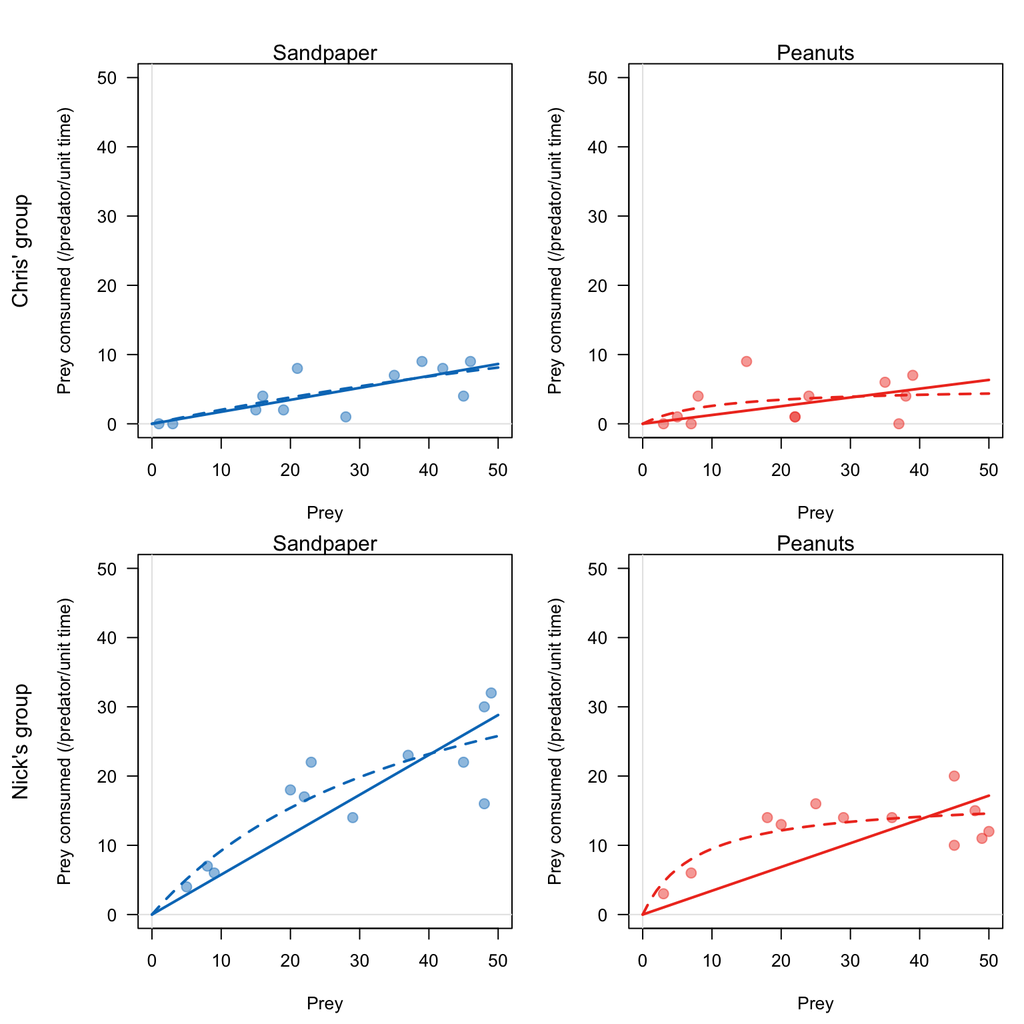

```r
# Make graphs for Chris' group
  par(mfrow = c(2, 2), mar = c(4.5, 4.5, 1, 1), oma = c(0, 2, 2, 0))
  # Sandpaper
  plot(x = NA, type ="n", xlim = c(0, 50), ylim = c(0, 50), xlab = "Prey", ylab = "Prey comsumed (/predator/unit time)", las = 1)
    mtext(side = 3, text = "Sandpaper")
    mtext(side = 2, line = 5, text = "Chris' group")
    abline(h = 0, v = 0, col = "grey90")
    points(x = sandCM_dat$Initial, y = sandCM_dat$Removed, las = 1, col = "#007ac177", pch = 19, cex = 1.25)
    lines(x = x_vec, y = sandCM_y, col = "#007ac1", lwd = 2)
    lines(x = x_vec, y = sandCM_nsly, col = "#007ac1", lty = 2, lwd = 2)
    # Peanuts
  plot(x = NA, type ="n", xlim = c(0, 50), ylim = c(0, 50), xlab = "Prey", ylab = "Prey comsumed (/predator/unit time)", las = 1)
  mtext(side = 3, text = "Peanuts")
  abline(h = 0, v = 0, col = "grey90")
  points(x = peaCM_dat$Initial, y = peaCM_dat$Removed, las = 1, col = "#ef3b2477", pch = 19, cex = 1.25)
  lines(x = x_vec, y = peaCM_y, col = "#ef3b24", lwd = 2)
  lines(x = x_vec, y = peaCM_nsly, col = "#ef3b24", lty = 2, lwd = 2)

# Make graphs for Nick's group
  # Sandpaper
  plot(x = NA, type ="n", xlim = c(0, 50), ylim = c(0, 50), xlab = "Prey", ylab = "Prey comsumed (/predator/unit time)", las = 1)
    mtext(side = 3, text = "Sandpaper")
    mtext(side = 2, line = 5, text = "Nick's group")
    abline(h = 0, v = 0, col = "grey90")
    points(x = sandNL_dat$Initial, y = sandNL_dat$Removed, las = 1, col = "#007ac177", pch = 19, cex = 1.25)
    lines(x = x_vec, y = sandNL_y, col = "#007ac1", lwd = 2)
    lines(x = x_vec, y = sandNL_nsly, col = "#007ac1", lty = 2, lwd = 2)
    # Peanuts
  plot(x = NA, type ="n", xlim = c(0, 50), ylim = c(0, 50), xlab = "Prey", ylab = "Prey comsumed (/predator/unit time)", las = 1)
  mtext(side = 3, text = "Peanuts")
  abline(h = 0, v = 0, col = "grey90")
  points(x = peaNL_dat$Initial, y = peaNL_dat$Removed, las = 1, col = "#ef3b2477", pch = 19, cex = 1.25)
  lines(x = x_vec, y = peaNL_y, col = "#ef3b24", lwd = 2)
  lines(x = x_vec, y = peaNL_nsly, col = "#ef3b24", lty = 2, lwd = 2)
```

### 5.2.2 Statistical results

```r
AIC(sandCM_lm, sandCM_nls)
```

```
##            df      AIC
## sandCM_lm   2 57.28630
## sandCM_nls  3 59.11403
```

This means that the linear model for Chris’ group is more parsimonious for sandpaper.

```r
AIC(peaCM_lm, peaCM_nls)
```

```
##           df      AIC
## peaCM_lm   2 63.13534
## peaCM_nls  3 63.70678
```

This means that the linear model is a more parsimonious (more explanatory relative to its complexity), but given that the AIC vales are nearly identical, we typically say neither is more parsimonious for peanuts.

```r
AIC(sandNL_lm, sandNL_nls)
```

```
##            df      AIC
## sandNL_lm   2 77.67669
## sandNL_nls  3 75.39705
```

This means that the non-linear model for Nick’s group is more parsimonious for sandpaper.

```r
AIC(peaNL_lm, peaNL_nls)
```

```
##           df      AIC
## peaNL_lm   2 76.79383
## peaNL_nls  3 64.65635
```

This means that the non-linear model for Nick’s group is more parsimonious for peanuts.